# Lista 1 – Gabarito

Geometria Analítica 2020.1

Prof. Fernando Náufel

11/10/2020 (modificado em 30/11/2020)

# Instruções

- Fique à vontade para consultar os coleguinhas e para usar programas como o Geogebra, mas somente soluções *analíticas* serão aceitas — nada de responder no olhômetro.
- Documente da forma mais clara possível todos os passos da resolução de cada questão.
- Entregue sua resolução no formato que você preferir: manuscrito escaneado ou fotografado, documento gerado via $\LaTeX$ etc. O importante é que a resolução esteja legível. Se você for fotografar sua resolução, use um aplicativo como [Clear Scan](https://play.google.com/store/apps/details?id=com.indymobileapp.document.scanner) para gerar um resultado melhor.
- Depois que você entregar sua resolução, você será entrevistado por vídeo pelo professor para explicar pontos específicos das suas respostas.
- Bom trabalho.

# 1

Considere $a$ o seu número na lista de alunos da sua turma.

Considere a reta $r: x + y - a = 0$.

Considere uma reta $s$ paralela (e não coincidente) a $r$.

Considere um ponto $A \in r$ e um ponto $B \in s$ tais que $AB \perp r$.

Considere $P = (a, -a)$ o ponto médio de $AB$.

1. Quais as equações paramétricas de $s$?
2. Qual a distância entre $r$ e $s$?

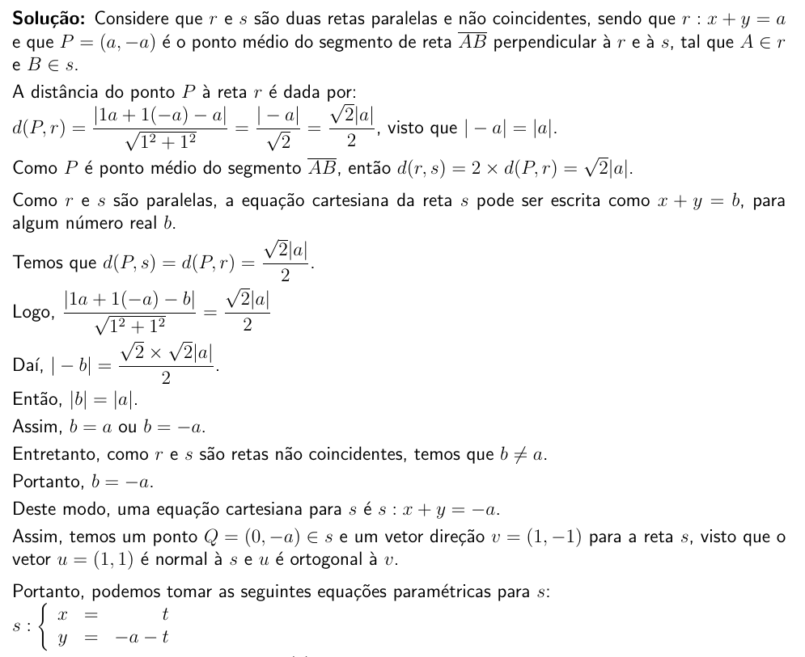

# 2

Considere $a = n - 20$, onde $n$ é o seu número na lista de alunos da sua turma.

Considere as retas (substituindo $a$ pelo valor que você calculou)
$$r: -(a - m)x + y - (a + m) = 0$$
e
$$t : y = a$$

Qual deve ser o valor de $m$ para que $r$ e $t$ formem um ângulo de $\frac{\pi}{6}$?

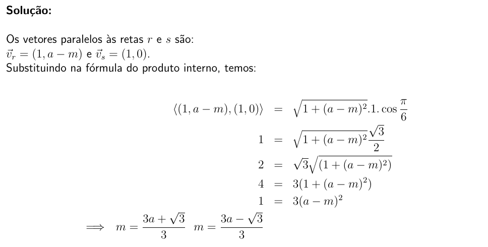

# 3

Considere $a$ o seu número na lista de alunos da sua turma.

Quais devem ser os valores de $m$ e $n$ para que o vetor $\vec w = \left( \frac{m}{5}, n + 9a \right)$ seja a projeção ortogonal de $\vec v = (m,n)$ sobre $\vec u = (-3,4)$?

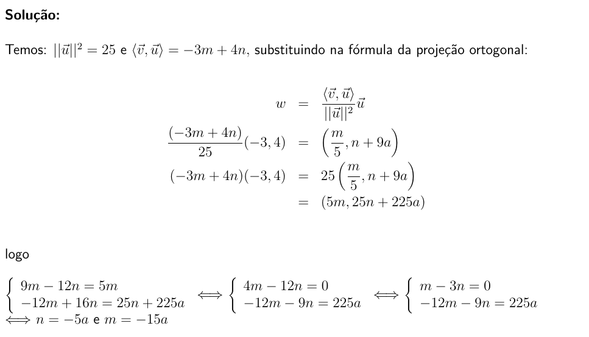